# Cost-Effectiveness of Renin-Guided Treatment of Hypertension | American Journal of Hypertension | Oxford Academic

[figure not shown]

[Journals](https://academic.oup.com/journals)

[Books](https://academic.oup.com/books)

[figure not shown]

Article Navigation

[figure not shown]

Volume 26

Issue 11

November 2013

### Article Contents

Journal Article [Editor's Choice](https://academic.oup.com/ajh/search-results?f_OUPSeries=Editor%27s+Choice)

# Cost-Effectiveness of Renin-Guided Treatment of Hypertension

Steven M. Smith, Jonathan D. Campbell

*American Journal of Hypertension*, Volume 26, Issue 11, November 2013, Pages 1303–1310, https://doi.org/10.1093/ajh/hpt099

Published:

03 October 2013

Article history

## Abstract

BACKGROUND

A plasma renin activity (PRA)–guided strategy is more effective than standard care in treating hypertension (HTN). However, its clinical implementation has been slow, presumably due in part to economic concerns. We estimated the cost effectiveness of a PRA-guided treatment strategy compared with standard care in a treated but uncontrolled HTN population.

METHODS

We estimated costs, quality-adjusted life years (QALYs), and the incremental cost-effectiveness ratio (ICER) of PRA-guided therapy compared to standard care using a state-transition simulation model with alternate patient characteristic scenarios and sensitivity analyses. Patient-specific inputs for the base case scenario, males average age 63 years, reflected best available data from a recent clinical trial of PRA-guided therapy. Transition probabilities were estimated using Framingham risk equations or derived from the literature; costs and utilities were derived from the literature.

RESULTS

In the base case scenario for males, the lifetime discounted costs and QALYs were $23,648 and 12.727 for PRA-guided therapy and $22,077 and 12.618 for standard care, respectively. The base case ICER was $14,497/QALY gained. In alternative scenario analyses varying patient input parameters, the results were sensitive to age, gender, baseline systolic blood pressure, and the addition of cardiovascular risk factors. Univariate sensitivity analyses demonstrated that results were most sensitive to varying the treatment effect of PRA-guided therapy and the cost of the PRA test.

CONCLUSIONS

Our results suggest that PRA-guided therapy compared with standard care increases QALYs and medical costs in most scenarios. PRA-guided therapy appears to be most cost effective in younger persons and those with more cardiovascular risk factors.

blood pressure, cost-effectiveness, hypertension, pharmacoeconomics, plasma renin activity, renin-guided therapy.

Topic:

- hypertension
- [framingham heart study](https://academic.oup.com/ajh/search-results?f_SemanticFilterTopics=framingham%20heart%20study)
- [heart disease risk factors](https://academic.oup.com/ajh/search-results?f_SemanticFilterTopics=heart%20disease%20risk%20factors)
- renin
- [systolic blood pressure](https://academic.oup.com/ajh/search-results?f_SemanticFilterTopics=systolic%20blood%20pressure)
- [cost effectiveness](https://academic.oup.com/ajh/search-results?f_SemanticFilterTopics=cost%20effectiveness)
- [quality-adjusted life years](https://academic.oup.com/ajh/search-results?f_SemanticFilterTopics=quality-adjusted%20life%20years)
- gender
- [sensitivity analysis](https://academic.oup.com/ajh/search-results?f_SemanticFilterTopics=sensitivity%20analysis)
- [standard of care](https://academic.oup.com/ajh/search-results?f_SemanticFilterTopics=standard%20of%20care)
- [plasma renin activity](https://academic.oup.com/ajh/search-results?f_SemanticFilterTopics=plasma%20renin%20activity)

Issue Section:

[Original Article](https://academic.oup.com/ajh/search-results?f_TocHeadingTitle=Original+Article)

Hypertension (HTN) is the most prevalent chronic condition affecting adults, contributing to substantial morbidity and mortality globally.<sup>1</sup> Despite the development of a wide armamentarium of well-tolerated and effective therapies, HTN control remains suboptimal in the United States.<sup>2</sup> Current US HTN treatment guidelines provide recommendations for specific therapeutic classes for patients with compelling indications.<sup>3</sup> However, for patients with uncomplicated essential HTN, these guidelines recommend only that providers consider thiazide diuretics as initial monotherapy or as a component of initial combination therapy in those with stage 2 HTN at baseline. In the absence of specific drug recommendations for this patient population, some providers prescribe therapies with which they are most comfortable. However, only approximately 40–60% of patients respond to any given antihypertensive agent,<sup>4</sup><sup>,</sup><sup>5</sup> and 5–10% of patients may even exhibit pressor responses to antihypertensives.<sup>6</sup> Other providers tailor therapy decisions to patient demographics such as age or race/ethnicity. When employed elegantly, this strategy can be useful; however, it relies on population statistics that may not be accurate for all persons in a given group. Furthermore, this strategy is of little use in patients who are already treated but remain uncontrolled. Finally, a common practice in the United States is stepped care, whereby antihypertensive agents are added sequentially to achieve blood pressure (BP) control; however, agents that are ineffective or only minimally effective are rarely discontinued. Taken together, these current strategies are clearly suboptimal given that >1 in 3 treated hypertensive patients in the United States remain uncontrolled.<sup>2</sup>

One strategy that has received renewed interest in recent years is the use of patient-level plasma renin activity (PRA) to guide selection of antihypertensive therapy. This concept posits that all chronic BP elevations are sustained by some degree of body sodium volume content or renin-angiotensin-aldosterone system (RAAS)–attributable vasoconstriction.<sup>7</sup> The degree to which either of these pathologies contributes to chronic elevations in BP can be assessed by measuring PRA; thus, patients with chronic HTN can be classified as having predominantly volume-dependent (V) HTN or renin-angiotensin vasoconstriction-dependent (R) HTN at any given point in time. Likewise, all antihypertensives can be generally classified as “anti-V” drugs (e.g., diuretics) or “anti-R” drugs (e.g., angiotensin-converting enzyme inhibitors), according to their major antihypertensive mechanism of action. Thus, patients with V HTN would be expected to respond better to an anti-V drug than an anti-R drug and vice versa for patients with R HTN.

A recent randomized controlled trial found a PRA-guided antihypertensive treatment strategy to be substantially more effective in reducing BP and achieving HTN control than standard care from clinical HTN specialists.<sup>8</sup> In this small study of 77 subjects with treated but uncontrolled HTN, mean systolic BP was reduced by 29mm Hg in the PRA-guided treatment group compared with a reduction of only 19mm Hg in the group treated by clinical HTN specialists from a baseline systolic BP of approximately 155mm Hg (*P* = 0.03). Additionally, 74% of subjects in the PRA-guided treatment group were controlled at study end compared with only 59% in the HTN specialist group (*P* = 0.17). Finally, from baseline to the final visit, the net difference in average number of prescribed BP medications between treatment groups was 1.2 per V patient (*P* = 0.01) and 0.5 per R patient (*P* = 0.15), both favoring the PRA-guided treatment group. This finding suggests that, at least for patients clearly identified as having low- or high-renin status, a PRA-guided strategy may reduce unnecessary medication use in addition to providing more substantial BP lowering.<sup>8</sup>

The PRA-guided strategy appears promising; however, two issues have limited broader uptake of this strategy: perceived complexity of PRA testing and cost. Technological improvements and a better understanding of (perceived) confounding factors have largely mitigated the first issue.<sup>7</sup> In addition, the cost of the PRA test has been reduced substantially in recent years. Yet, many clinicians still regard the PRA test as an unnecessary cost and unnecessary aid for treating HTN. Consequently, we aimed to determine the cost effectiveness of using PRA to guide antihypertensive therapy in patients with treated but uncontrolled HTN.

## METHODS

### Model description

A Markov model was developed that incorporated future events, costs, and utilities in an average person with uncontrolled HTN who was treated according to a PRA-guided strategy compared with standard care from a HTN specialist. The model operates by applying the additional average reduction in systolic BP resulting from PRA-guided therapy (vs. clinical HTN specialist-guided therapy) to published risk prediction models, thereby applying associations between systolic BP and significant clinical events. The patient entered the model with uncomplicated and uncontrolled HTN that was currently treated. The patient could then remain in a hypertensive state or progress to end-stage renal disease (ESRD), acute myocardial infarction (MI), congestive heart failure (CHF), stroke, or directly to the absorbable death state (Figure 1). If the patient progressed to one of the disease states, he or she could remain in that state or progress to other states or to death. The cycle length was 1 year and the time horizon was 30 years. The model was developed using spreadsheet software (Excel 2010, Microsoft Corp., Redmond, WA).

Figure 1.

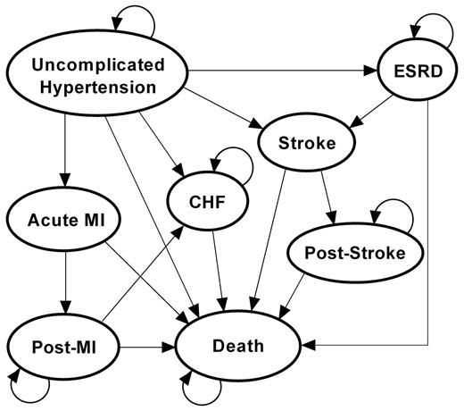

[Open in new tab](https://academic.oup.com/view-large/figure/1273064/ajhype_hpt099_f0001.jpeg)Download slide

State transition schematic. A patient starts in the uncomplicated hypertension state and can then transition to acute myocardial infarction (MI), congestive heart failure (CHF), stroke, or end-stage renal disease (ESRD) or remain in the uncomplicated hypertension state. Subsequent transition pathways are indicated by one-way arrows. All transitions occurred on a yearly basis.

### Model assumptions

Incidence probabilities were estimated and annualized using Framingham regression equations or point-based systems for CHF,<sup>9</sup> stroke,<sup>10</sup> acute MI,<sup>11</sup> or ESRD.<sup>12</sup> Each input variable used to estimate these incidence probabilities was the same in both treatment strategies except for BP, where a PRA-guided strategy was assumed to elicit a 10-mm Hg greater reduction in systolic BP, on average, than treatment by a clinical HTN specialist.<sup>8</sup> Thus, in the base case scenario, SBP was reduced by 29mm Hg with PRA-guided therapy compared with 19mm Hg with standard care from a HTN specialist, which is consistent with the aforementioned PRA-guided therapy randomized controlled trial.<sup>8</sup> The incidence probability of death from the uncomplicated HTN state was estimated using US national death rate estimates according to age and gender.<sup>13</sup> All other transition probabilities between states other than those originating from the uncomplicated HTN state were static (i.e., the same regardless of treatment effect) and based on literature estimates (Table 1).

Table 1.

Input parameters for base case scenario

| Parameter | Base case value |  | Range | Reference |
| --- | --- | --- | --- | --- |
| *Input parameters that vary based on treatment strategy* |  |  |  |  |
| *Transition probabilities* | PRA-guided | Standard Care |  |  |
| HTN to acute MI | 0.0009024 | 0.0012083 | — | Calculated |
| HTN to CHF | 0.00147234 | 0.00151993 | — | Calculated |
| HTN to stroke | 0.00208031 | 0.00221544 | — | Calculated |
| HTN to ESRD | 0.00009343 | 0.00012983 | — | Calculated |
| *Input parameters invariant to treatment strategy* |  |  |  |  |
| *Transition probabilities* |  |  |  |  |
| HTN to death | 0.008095 |  | Based on age/gender | 13 |
| Acute MI to death | 0.006894 |  | — | 15 |
| Acute MI to post-MI | 0.993106 |  | — | Calculated |
| Post-MI to CHF | 0.07396 |  | — | 15 |
| Post-MI to death | 0.02568609 |  | — | 15 |
| Remain in post-MI | 0.90035391 |  | — | Calculated |
| CHF to death | 0.34 |  | — | 16 |
| Remain in CHF | 0.66 |  | — | Calculated |
| ESRD to stroke | 0.185 |  | — | 17 |
| ESRD to death | 0.141 |  | — | 17 |
| Remain in ESRD | 0.674 |  | — | Calculated |
| Stroke to death | 0.069 |  | — | 18 |
| Stroke to post-stroke | 0.931 |  | — | Calculated |
| Post-stroke to death | 0.236 |  | — | 18 |
| Remain in post-stroke | 0.764 |  | — | Calculated |
| *Costs ($)*<sup>*a*</sup> |  |  |  |  |
| HTN | 914 |  | 214–1,427 | 19 |
| Stroke (once) | 19,612 |  | 9,344–69,256 | 20 |
| Post-stroke (annually) | 32,431 |  | 8,551–69,171 | 21 |
| Acute MI (once) | 22,245 |  | 8,697–50,843 | 22 |
| Post-MI (annually) | 3,948 |  | 0–11,060 | 23 |
| CHF (annually) | 5,488 |  | 4,167–11,481 | 24 |
| ESRD (annually) | 75,000 |  | 53,935–89,882 | 17 |
| PRA test (once) | 150 |  | 50–300 | Estimated |
| *Utilities* |  |  |  |  |
| HTN | 0.96 |  | 0.79–0.98 | 25 |
| Stroke | 0.63 |  | 0.26–0.92 | 26, 27 |
| Acute MI | 0.76 |  | 0.5–0.87 | 28, 29 |
| Post–MI | 0.88 |  | 0.67–0.94 | 26, 30 |
| CHF | 0.71 |  | 0.43–0.84 | 31, 32 |
| ESRD | 0.63 |  | 0.46–0.84 | 33 |

Abbreviations: CHF, congestive heart failure; ESRD, end-stage renal disease; HTN, hypertension; MI, myocardial infarction; PRA, plasma renin activity.

<sup>a</sup>Costs represented in 2012 US dollars.

[Open in new tab](https://academic.oup.com/view-large/1273067)

Table 1.

Input parameters for base case scenario

[output not shown]

Abbreviations: CHF, congestive heart failure; ESRD, end-stage renal disease; HTN, hypertension; MI, myocardial infarction; PRA, plasma renin activity.

<sup>a</sup>Costs represented in 2012 US dollars.

[Open in new tab](https://academic.oup.com/view-large/1273067)

All costs were expressed in 2012 US dollars and discounted at an annual rate of 3%. Costs for medication regimens were not included in the model since they were assumed to be similar regardless of treatment strategy. The PRA test was estimated to cost $150 per test in the base case scenario. This cost incorporated both the estimated cost for a lab to analyze the sample<sup>7</sup> as well as a conservative estimate of the administrative fees and fees associated with the blood draw.

Utilities were obtained from a review of the literature (Table 1) and adjusted according to age.<sup>14</sup> No adjustments were made for a patient transitioning from one intermediary state (e.g., post-MI) to another (e.g., CHF). Likewise, no adjustments were made for adverse effects stemming from medication use as these were conservatively assumed to be similar regardless of treatment strategy. Moreover, since the present analysis is not testing specific treatments, any treatment that caused adverse effects would be changed to another medication, regardless of the treatment strategy. Quality-adjusted life-years (QALYs)—a measure that incorporates both length of life and health-related quality of life—represented the utility of a disease state multiplied by the duration of the disease state. Thus, for a person with CHF utility for 4 years, 4×0.71 (utility for CHF), 2.84 QALYs would be contributed.

### Analyses

In all analyses, the intervention was treatment guided by measuring PRA level (PRA-guided therapy), whereas the best medical management from a clinical HTN specialist was the comparator (standard care). The primary outcome in all analyses was the incremental cost-effectiveness ratio (ICER). The ICER represents the additional cost per additional unit of effect (e.g., QALY) associated with the more effective strategy. Consequently, ICERs can be compared across widely varied interventions or to a prespecified threshold value to aid decision makers in determining willingness to pay for a particular treatment or intervention.

The primary analysis (base case scenario) was modeled on the baseline demographic and clinical variables in the PRA-guided therapy randomized controlled trial.<sup>8</sup> Briefly, these patients were, on average, aged 63 years, with treated but uncontrolled stage 1 HTN, on average (mean baseline BP = 155/89mm Hg), and otherwise stable without major cardiovascular (except for diabetes) or end-stage renal comorbidities. Table 2 summarizes the base case patient characteristics for a male and female with equivalent risk factors. Baseline cholesterol parameters reference data from the Antihypertensive and Lipid Lowering Treatment to Prevent Heart Attack Trial (ALLHAT)<sup>34</sup> and Anglo-Scandinavian Cardiac Outcomes Trial (ASCOT)<sup>35</sup> since no data were available on these parameters from the PRA-guided therapy trial. Univariate sensitivity analyses were performed by varying cost and utility inputs. Several additional scenario analyses were also performed by varying demographic (e.g., age, gender) and clinical inputs (e.g., baseline BP, smoking status) to determine whether the type of patient impacted cost effectiveness.

Table 2.

Base case and alternative scenario analyses

| Parameter | Base case male | Base case female | Scenario 1 | Scenario 2 | Scenario 3 | Scenario 4 |
| --- | --- | --- | --- | --- | --- | --- |
| Gender | Male | **Female** | Male | **Female** | **Female** | Male |
| Age, y | 63 | 63 | **56** | **56** | 63 | 63 |
| Baseline systolic BP, mm Hg | 155 | 155 | 155 | 155 | **175** | **175** |
| Baseline diastolic BP, mm Hg | 89 | 89 | 89 | 89 | 89 | 89 |
| Baseline heart rate, bpm | 85 | 85 | 85 | 85 | 85 | 85 |
| Total cholesterol, mg/dl | 225 | 225 | 225 | 225 | 225 | 225 |
| High-density lipoprotein, mg/dl | 50 | 50 | **30** | 50 | 50 | 50 |
| Smoker | No | No | No | **Yes** | **Yes** | No |
| Diabetes | No | No | No | No | **Yes** | **Yes** |
| Left ventricular hypertrophy | No | No | **Yes** | No | No | No |
| Cardiomegaly | No | No | No | No | No | No |
| Valve disease | No | No | No | No | No | No |
| Vital capacity, L | 2.5 | 2.5 | 2.5 | 2.5 | 2.5 | 2.5 |
| Atrial fibrillation | No | No | No | No | No | **Yes** |
| CVD | No | No | No | No | No | No |
| Treatment effect, mm Hg | 10 | 10 | 10 | 10 | 10 | 10 |
| Total cost for PRA strategy | $23,648 | $21,270 | $31,053 | $26,134 | $35,431 | $36,615 |
| Total cost for SC | $22,077 | $19,037 | $29,917 | $24,225 | $33,562 | $35,918 |
| Total QALYs for PRA strategy | 12.727 | 14.998 | 14.767 | 18.073 | 13.209 | 11.667 |
| Total QALYs for SC | 12.618 | 14.942 | 14.510 | 17.934 | 13.093 | 11.469 |
| Incremental cost<sup>a</sup> | $1,571 | $2,232 | $1,135 | $1,909 | $1,869 | $697 |
| Incremental QALYs<sup>b</sup> | 0.108 | 0.055 | 0.258 | 0.139 | 0.117 | 0.199 |
| ICER<sup>c</sup> | $14,497 | $40,449 | $4,408 | $13,716 | $16,035 | $3,506 |

Rounding to the nearest dollar and nearest thousandth for QALYs was conducted after computation of the incremental findings. Therefore, some incremental findings may be slightly different than the exact subtraction of PRA strategy minus SC due to rounding. Base case values derived from published data by Egan *et al*.<sup>8</sup> and ALLHAT and ASCOT data.<sup>34</sup><sup>,</sup><sup>35</sup> Bolded items represent departure from base case male scenario.

Abbreviations: BP, blood pressure; ICER, incremental cost-effectiveness ratio; PRA, plasma renin activity; QALY, quality-adjusted life year; SC, standard care; SBP, systolic blood pressure.

<sup>a</sup>Incremental cost represents total cost for PRA strategy minus total cost for SC.<sup>b</sup>Incremental QALYs represents total QALYs for PRA strategy minus total QALYs for SC. <sup>c</sup>ICER represents incremental cost divided by incremental QALYs.

[Open in new tab](https://academic.oup.com/view-large/1273073)

Table 2.

Base case and alternative scenario analyses

[output not shown]

Rounding to the nearest dollar and nearest thousandth for QALYs was conducted after computation of the incremental findings. Therefore, some incremental findings may be slightly different than the exact subtraction of PRA strategy minus SC due to rounding. Base case values derived from published data by Egan *et al*.<sup>8</sup> and ALLHAT and ASCOT data.<sup>34</sup><sup>,</sup><sup>35</sup> Bolded items represent departure from base case male scenario.

Abbreviations: BP, blood pressure; ICER, incremental cost-effectiveness ratio; PRA, plasma renin activity; QALY, quality-adjusted life year; SC, standard care; SBP, systolic blood pressure.

<sup>a</sup>Incremental cost represents total cost for PRA strategy minus total cost for SC.<sup>b</sup>Incremental QALYs represents total QALYs for PRA strategy minus total QALYs for SC. <sup>c</sup>ICER represents incremental cost divided by incremental QALYs.

[Open in new tab](https://academic.oup.com/view-large/1273073)

## RESULTS

### Base case scenario

In the base case scenario of a male patient, the PRA-guided strategy, which lowered systolic BP by an additional 10mm Hg over standard care, resulted in discounted total costs of $23,648 and a total QALY gain of 12.727 (Table 2). Corresponding standard care discounted total costs were $22,077 with a total QALY gain of 12.618. Thus, incremental costs and QALYs in the base case male patient scenario were $1,571 and 0.108, respectively, resulting in an ICER of $14,497 per QALY gained for lowering systolic BP with a PRA-guided strategy.

In the base case scenario of a female patient, the PRA-guided strategy resulted in discounted total costs of $21,270 and a total QALY gain of 14.998 (Table 2). Standard care discounted total costs were $19,037 with a total gain in QALYs of 14.942. Accordingly, incremental costs and QALYs were $2,232 and 0.055, respectively. Thus, the ICER for lowering systolic BP with a PRA-guided strategy was $40,449 per QALY gained in the base case female scenario.

### Alternative scenario analyses

In additional alternative scenario analyses in which patient-specific input parameters were varied from the base case, the ICER ranged from approximately $3,506 to $16,035 per QALY gained (Table 2, alternate scenarios 1–4). Figure 2 displays the ICER across the age range of 54 to 79 years according to gender. For both males and females, the ICER increased with age and the ICER remained <$100,000 per QALY gained for females up to age 71 years and for males up to age 76 years. The addition of cardiovascular risk factors (e.g., smoking, diabetes, left ventricular hypertrophy, atrial fibrillation, higher baseline systolic BP) generally resulted in a lower ICER compared with the base case scenarios (Table 2).

Figure 2.

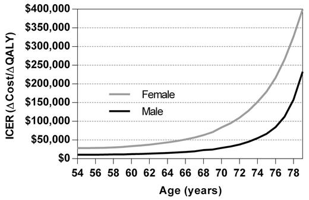

[Open in new tab](https://academic.oup.com/view-large/figure/1273080/ajhype_hpt099_f0002.jpeg)Download slide

Incremental cost-effectiveness ratios for females and males according to age, with all other variables held constant from base case scenario.

### Univariate sensitivity analyses

In univariate sensitivity analyses, the ICER was estimated by varying treatment effect, transition probabilities, costs, and utilities. The parameters with the greatest impact on the ICER were treatment effect, the cost of the PRA test, and HTN utility (Figure 3). Specifically, using a treatment effect of 20mm Hg (i.e., a 20-mm Hg greater reduction, instead of a 10-mm Hg greater reduction, with PRA-guided strategy compared with standard care), the ICER was $1,110 per QALY gained, whereas if the treatment effect was conservatively estimated at 5mm Hg, the ICER was $43,078 per QALY gained. At a cost of $50 per PRA test, the PRA-guided strategy dominated standard care with a higher QALY and lower discounted total costs. Conversely, at a cost of $300 per PRA test, the ICER was estimated at $41,630 per QALY gained.

Figure 3.

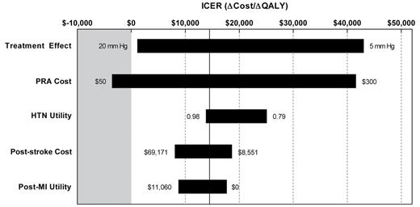

[Open in new tab](https://academic.oup.com/view-large/figure/1273083/ajhype_hpt099_f0003.jpeg)Download slide

Tornado plot for univariate sensitivity analyses for male base case scenario comparing plasma renin activity (PRA)–guided therapy vs. standard care from a hypertension specialist. Values outside of the black bars represent the range analyzed in the univariate sensitivity analysis where the number to the left side of the bar corresponds to the low end of the incremental cost-effectiveness ratio (ICER) estimate (represented by the left edge of the bar); the number to the right side of the bar corresponds to the high end of the ICER estimate (represented by the right edge of the bar). The black vertical line running through each bar represents the base case ICER of $14,497 per quality-adjusted life year (QALY) gained. The area shaded gray represents domination (ie, QALYs gained at a lower cost) of PRA-guided therapy over standard care. Variables that had no substantial impact on the ICER variability (defined as <$5,000 difference between the min and max ICER) are not shown.

## DISCUSSION

In the present study—to our knowledge, the first to assess the cost effectiveness of a PRA-guided strategy— we found that a PRA-guided strategy that lowered mean systolic BP by 10mm Hg more than standard care from a clinical HTN specialist is likely cost effective in the management of treated but uncontrolled HTN, depending on the willingness-to-pay threshold. In the base case scenario of a 63-year-old male with treated HTN (baseline BP = 155/89mm Hg) and without significant cardiovascular disease, the PRA-guided strategy, as compared with standard care, was associated with an ICER of just <$15,000 per QALY gained; for a female with the same demographic and clinical parameter inputs, we found an ICER of just >$40,000 per QALY gained. For a person with greater cardiovascular risk than in our base case scenario, the ICER was substantially decreased in most cases, likely reflecting greater benefit afforded by BP reductions in high-risk patients. The one significant exception was increasing age: holding all other variables the same, the ICER increased substantially with age for both males and females. This finding is indicative of a diminishing return from tighter control of BP in older individuals since age and QALYs gained were inversely related.

These findings are significant given that a PRA-guided therapeutic strategy has been shown to significantly reduce BP and improve BP control rates compared with standard care from a HTN specialist.<sup>8</sup> Reductions in BP and HTN control have been consistently associated with a significantly lower risk of major adverse cardiovascular events; however, HTN control remains suboptimal in the United States and globally. Therefore, cost-effective and clinically effective strategies to improve BP control are urgently needed. Moreover, to be broadly implemented, these strategies must be widely available. Based on the present results and others, a PRA-guided strategy would appear to fit these criteria well.

Given the potential clinical impact of PRA-guided therapy, the present results suggest that, at least for younger individuals and those with higher cardiovascular risk, PRA-guided strategy may be a reasonable and cost-effective strategy to aid clinicians in improving BP control. From a payer perspective, these results suggest that across an insured population with HTN, reimbursement for PRA-guided therapy costs between approximately $15,000 and $40,000 per QALY gained, depending on risk reduction (and QALYs gained) afforded by a more rapid and more effective BP reduction. These ICERs are generally comparable to, or lower than, other nonpharmacologic strategies for reducing BP in hypertensive patients, including renal denervation (ICER = $31,460/QALY gained),<sup>19</sup> carotid body stimulation (ICER = $64,400/QALY gained),<sup>36</sup> and collaborative educational programs (ICER = $41,927 per life-year gained) aimed at improving treated but uncontrolled HTN.<sup>37</sup> In addition to cost effectiveness or the relative efficiency of an intervention, practical financial considerations should be made, including the affordability of the intervention. We found that as the size of the population that uses a PRA-guided strategy increases, the costs to the payer increase, ranging from an average of $697 (in high-risk patients) to $2,232 (in low-risk patients); these are additional costs over the patient’s lifetime. Although not incorporated in the present study, a PRA-guided strategy also may result in a smaller number of medications for an individual patient,<sup>8</sup> resulting in potentially lower medication costs and greater medication adherence. In turn, lower medication costs and greater medication adherence also likely lead to less frequent healthcare visits for patients, resulting in additional cost reductions. Furthermore, the ability to better predict which antihypertensive agent a patient will respond to could minimize exposure to unnecessary, ineffective, or even potentially harmful medications. Finally, a noteworthy finding is that a PRA-guided strategy appears to dominate standard care from a HTN specialist when the cost of the PRA test was varied below $70 per test. This finding suggests that future reductions in the cost of PRA testing should warrant increased consideration of the PRA-guided treatment strategy since it may result in both cost savings and QALYs gained.

The present study has noteworthy limitations. First, the model assumed that the treatment effect of the PRA-guided strategy would be maintained over the long term; whether this is in fact true is not known as no long-term studies of PRA-guided strategies have been performed to date. Second, the present model analyzed BP response in hypothetical patients currently receiving treatment but not in previously untreated patients. Although a PRA-guided strategy is more effective in reducing population BP than prescribing based on demographic and clinical variables in previously treated patients,<sup>8</sup> the possibility remains that these two strategies are relatively comparable in previously untreated patients. Thus our results should not be extrapolated to a population of previously untreated hypertensive patients. Third, the model has a limited number of states—the major clinical sequelae of HTN—to which patients could transition and therefore may understate the impact of chronically elevated BP. However, this underestimation would be expected to bias our findings against the PRA-guided strategy, leading to more conservative estimates. Fourth, the incident probabilities were derived primarily from the Framingham cohort and therefore may not be applicable to all patients with HTN. In addition, the Framingham cohort does not represent an intervention study population per se. Thus risk reductions estimated using these data may differ from risk reductions stemming from clinical intervention trials testing the benefit of specific agents. However, published Framingham models do account for the presence (or absence) of antihypertensive treatment in predicting risk. Therefore, Framingham risk models are a commonly used and accepted method in economic analyses for projecting benefits of cardiovascular interventions.<sup>19</sup><sup>,</sup><sup>36</sup><sup>,</sup><sup>38</sup> Finally, the base case scenario parameter inputs were based largely on a relatively small clinical trial of PRA-guided therapy. Additional trials with larger sample size and more precise estimates of treatment effect will be useful in confirming the results of the present study.

In conclusion, our results suggest that a PRA-guided strategy for treating patients with treated but uncontrolled HTN may be cost effective, particularly for younger individuals and those with higher baseline cardiovascular risk. The primary drivers of ICER variability were age, cost of the PRA test, and the treatment effect (i.e., the effect on BP of a PRA-guided strategy vs. standard care from a HTN specialist). Future studies will need to confirm these findings, ideally incorporating data from larger clinical trials of PRA-guided therapy.

## DISCLOSURE

The authors declared no conflicts of interest.

## ACKNOWLEDGMENTS

The authors report no sources of support for the present work.

## REFERENCES

1.

Kearney

PM

Whelton

M

Reynolds

K

Muntner

P

Whelton

PK

He

J

.

Global burden of hypertension: Analysis of worldwide data

.

Lancet

2005

;

365

:

217

–

223

.

Google Scholar

Crossref

Find in my library

[PubMed](http://www.ncbi.nlm.nih.gov/pubmed/15652604)

[WorldCat](https://www.worldcat.org/search?q=ti:Global%20burden%20of%20hypertension%3A%20Analysis%20of%20worldwide%20data&qt=advanced&dblist=638)

2.

Go

AS

Mozaffarian

D

Roger

VL

Benjamin

EJ

Berry

JD

Borden

WB

Bravata

DM

Dai

S

Ford

ES

Fox

CS

Franco

S

Fullerton

HJ

Gillespie

C

Hailpern

SM

Heit

JA

Howard

VJ

Huffman

MD

Kissela

BM

Kittner

SJ

Lackland

DT

Lichtman

JH

Lisabeth

LD

Magid

D

Marcus

GM

Marelli

A

Matchar

DB

McGuire

DK

Mohler

ER

Moy

CS

Mussolino

ME

Nichol

G

Paynter

NP

Schreiner

PJ

Sorlie

PD

Stein

J

Turan

TN

Virani

SS

Wong

ND

Woo

D

Turner

MB

.

Heart disease and stroke statistics—2013 update a report from the American Heart Association

.

Circulation

2013

;

127

:

e6

–

e245

.

Google Scholar

[Crossref](http://dx.doi.org/10.1161/CIR.0b013e31828124ad)

[Find in my library](https://ufl-flvc.primo.exlibrisgroup.com/openurl/01FALSC_UFL/01FALSC_UFL:UFL?rft_id=info%3Adoi%2F10.1161%2FCIR.0b013e31828124ad)

[PubMed](http://www.ncbi.nlm.nih.gov/pubmed/23239837)

[WorldCat](https://www.worldcat.org/search?q=ti:Heart%20disease%20and%20stroke%20statistics%E2%80%942013%20update%20a%20report%20from%20the%20American%20Heart%20Association&qt=advanced&dblist=638)

3.

Chobanian

AV

Bakris

GL

Black

HR

Cushman

WC

Green

LA

Izzo

JL

Jones

DW

Materson

BJ

Oparil

S

Wright

JT

Roccella

EJ

;

National Heart, Lung, and Blood Institute Joint National Committee on Prevention, Detection, Evaluation, and Treatment of High Blood Pressure; National High Blood Pressure Education Program Coordinating Committee

.

The seventh report of the Joint National Committee on Prevention, Detection, Evaluation, and Treatment of high blood pressure: The JNC 7 report

.

JAMA

2003

;

289

:

2560

–

2572

.

Google Scholar

[Crossref](http://dx.doi.org/10.1001/jama.289.19.2560)

[Find in my library](https://ufl-flvc.primo.exlibrisgroup.com/openurl/01FALSC_UFL/01FALSC_UFL:UFL?rft_id=info%3Adoi%2F10.1001%2Fjama.289.19.2560)

[PubMed](http://www.ncbi.nlm.nih.gov/pubmed/12748199)

WorldCat

4.

Materson

BJ

Reda

DJ

Cushman

WC

Massie

BM

Freis

ED

Kochar

MS

Hamburger

RJ

Fye

C

Lakshman

R

Gottdiener

J

.

Single-drug therapy for hypertension in men. A comparison of six antihypertensive agents with placebo. The Department of Veterans Affairs cooperative study group on antihypertensive agents

.

N Engl J Med

1993

;

328

:

914

–

921

.

Google Scholar

[Crossref](http://dx.doi.org/10.1056/NEJM199304013281303)

[Find in my library](https://ufl-flvc.primo.exlibrisgroup.com/openurl/01FALSC_UFL/01FALSC_UFL:UFL?rft_id=info%3Adoi%2F10.1056%2FNEJM199304013281303)

[PubMed](http://www.ncbi.nlm.nih.gov/pubmed/8446138)

WorldCat

5.

Comparison of propranolol and hydrochlorothiazide for the initial treatment of hypertension

.

II. Results of long-term therapy. Veterans administration cooperative study group on antihypertensive agents

.

JAMA

1982

;

248

:

2004

–

2011

.

Google Scholar

[Crossref](http://dx.doi.org/10.1001/jama.1982.03330160052024)

[Find in my library](https://ufl-flvc.primo.exlibrisgroup.com/openurl/01FALSC_UFL/01FALSC_UFL:UFL?rft_id=info%3Adoi%2F10.1001%2Fjama.1982.03330160052024)

[PubMed](http://www.ncbi.nlm.nih.gov/pubmed/6750167)

[WorldCat](https://www.worldcat.org/search?q=ti:II.%20Results%20of%20long-term%20therapy.%20Veterans%20administration%20cooperative%20study%20group%20on%20antihypertensive%20agents&qt=advanced&dblist=638)

6.

Alderman

MH

Cohen

HW

Sealey

JE

Laragh

JH

.

Pressor responses to antihypertensive drug types

.

Am J Hypertens

2010

;

23

:

1031

–

1037

.

Google Scholar

[Crossref](http://dx.doi.org/10.1038/ajh.2010.114)

[Find in my library](https://ufl-flvc.primo.exlibrisgroup.com/openurl/01FALSC_UFL/01FALSC_UFL:UFL?rft_id=info%3Adoi%2F10.1038%2Fajh.2010.114)

[PubMed](http://www.ncbi.nlm.nih.gov/pubmed/20725055)

[WorldCat](https://www.worldcat.org/search?q=ti:Pressor%20responses%20to%20antihypertensive%20drug%20types&qt=advanced&dblist=638)

7.

Laragh

JH

Sealey

JE

.

The plasma renin test reveals the contribution of body sodium-volume content (v) and renin-angiotensin (r) vasoconstriction to long-term blood pressure

.

Am J Hypertens

2011

;

24

:

1164

–

1180

.

Google Scholar

[Crossref](http://dx.doi.org/10.1038/ajh.2011.171)

[Find in my library](https://ufl-flvc.primo.exlibrisgroup.com/openurl/01FALSC_UFL/01FALSC_UFL:UFL?rft_id=info%3Adoi%2F10.1038%2Fajh.2011.171)

[PubMed](http://www.ncbi.nlm.nih.gov/pubmed/21938070)

WorldCat

8.

Egan

BM

Basile

JN

Rehman

SU

Davis

PB

Grob

CH

Riehle

JF

Walters

CA

Lackland

DT

Merali

C

Sealey

JE

Laragh

JH

.

Plasma renin test-guided drug treatment algorithm for correcting patients with treated but uncontrolled hypertension: A randomized controlled trial

.

Am J Hypertens

2009

;

22

:

792

–

801

.

Google Scholar

[Crossref](http://dx.doi.org/10.1038/ajh.2009.63)

[Find in my library](https://ufl-flvc.primo.exlibrisgroup.com/openurl/01FALSC_UFL/01FALSC_UFL:UFL?rft_id=info%3Adoi%2F10.1038%2Fajh.2009.63)

[PubMed](http://www.ncbi.nlm.nih.gov/pubmed/19373213)

WorldCat

9.

Kannel

WB

D’Agostino

RB

Silbershatz

H

Belanger

AJ

Wilson

PW

Levy

D

.

Profile for estimating risk of heart failure

.

Arch Intern Med

1999

;

159

:

1197

–

1204

.

Google Scholar

[Crossref](http://dx.doi.org/10.1001/archinte.159.11.1197)

[Find in my library](https://ufl-flvc.primo.exlibrisgroup.com/openurl/01FALSC_UFL/01FALSC_UFL:UFL?rft_id=info%3Adoi%2F10.1001%2Farchinte.159.11.1197)

[PubMed](http://www.ncbi.nlm.nih.gov/pubmed/10371227)

[WorldCat](https://www.worldcat.org/search?q=ti:Profile%20for%20estimating%20risk%20of%20heart%20failure&qt=advanced&dblist=638)

10.

D’Agostino

RB

Wolf

PA

Belanger

AJ

Kannel

WB

.

Stroke risk profile: Adjustment for antihypertensive medication. The Framingham study

.

Stroke

1994

;

25

:

40

–

43

.

Google Scholar

[Crossref](http://dx.doi.org/10.1161/01.STR.25.1.40)

[Find in my library](https://ufl-flvc.primo.exlibrisgroup.com/openurl/01FALSC_UFL/01FALSC_UFL:UFL?rft_id=info%3Adoi%2F10.1161%2F01.STR.25.1.40)

[PubMed](http://www.ncbi.nlm.nih.gov/pubmed/8266381)

[WorldCat](https://www.worldcat.org/search?q=ti:Stroke%20risk%20profile%3A%20Adjustment%20for%20antihypertensive%20medication.%20The%20Framingham%20study&qt=advanced&dblist=638)

11.

Anderson

KM

Odell

PM

Wilson

PW

Kannel

WB

.

Cardiovascular disease risk profiles

.

Am Heart J

1991

;

121

:

293

–

298

.

Google Scholar

Crossref

Find in my library

[PubMed](http://www.ncbi.nlm.nih.gov/pubmed/1985385)

[WorldCat](https://www.worldcat.org/search?q=ti:Cardiovascular%20disease%20risk%20profiles&qt=advanced&dblist=638)

12.

Hsu

CY

McCulloch

CE

Darbinian

J

Go

AS

Iribarren

C

.

Elevated blood pressure and risk of end-stage renal disease in subjects without baseline kidney disease

.

Arch Intern Med

2005

;

165

:

923

–

928

.

Google Scholar

[Crossref](http://dx.doi.org/10.1001/archinte.165.8.923)

[Find in my library](https://ufl-flvc.primo.exlibrisgroup.com/openurl/01FALSC_UFL/01FALSC_UFL:UFL?rft_id=info%3Adoi%2F10.1001%2Farchinte.165.8.923)

[PubMed](http://www.ncbi.nlm.nih.gov/pubmed/15851645)

[WorldCat](https://www.worldcat.org/search?q=ti:Elevated%20blood%20pressure%20and%20risk%20of%20end-stage%20renal%20disease%20in%20subjects%20without%20baseline%20kidney%20disease&qt=advanced&dblist=638)

13.

Kochanek

KD

Xu

J

Murphy

SL

Minino

AM

Kung

H-C

.

Deaths: Final data for 2009

.

Natl Vital Stat Rep

2011

;

60

:

117

.

Google Scholar

Find in my library

[WorldCat](https://www.worldcat.org/search?q=ti:Deaths%3A%20Final%20data%20for%202009&qt=advanced&dblist=638)

14.

Sullivan

PW

Ghushchyan

V

.

Preference-based EQ-5D index scores for chronic conditions in the United States

.

Med Decis Making

2006

;

26

:

410

–

420

.

Google Scholar

[Crossref](http://dx.doi.org/10.1177/0272989X06290495)

[Find in my library](https://ufl-flvc.primo.exlibrisgroup.com/openurl/01FALSC_UFL/01FALSC_UFL:UFL?rft_id=info%3Adoi%2F10.1177%2F0272989X06290495)

[PubMed](http://www.ncbi.nlm.nih.gov/pubmed/16855129)

[WorldCat](https://www.worldcat.org/search?q=ti:Preference-based%20EQ-5D%20index%20scores%20for%20chronic%20conditions%20in%20the%20United%20States&qt=advanced&dblist=638)

15.

Velagaleti

RS

Pencina

MJ

Murabito

JM

Wang

TJ

Parikh

NI

D’Agostino

RB

Levy

D

Kannel

WB

Vasan

RS

.

Long-term trends in the incidence of heart failure after myocardial infarction

.

Circulation

2008

;

118

:

2057

–

2062

.

Google Scholar

[Crossref](http://dx.doi.org/10.1161/CIRCULATIONAHA.108.784215)

[Find in my library](https://ufl-flvc.primo.exlibrisgroup.com/openurl/01FALSC_UFL/01FALSC_UFL:UFL?rft_id=info%3Adoi%2F10.1161%2FCIRCULATIONAHA.108.784215)

[PubMed](http://www.ncbi.nlm.nih.gov/pubmed/18955667)

[WorldCat](https://www.worldcat.org/search?q=ti:Long-term%20trends%20in%20the%20incidence%20of%20heart%20failure%20after%20myocardial%20infarction&qt=advanced&dblist=638)

16.

Ho

KK

Anderson

KM

Kannel

WB

Grossman

W

Levy

D

.

Survival after the onset of congestive heart failure in Framingham Heart Study subjects

.

Circulation

1993

;

88

:

107

–

115

.

Google Scholar

[Crossref](http://dx.doi.org/10.1161/01.CIR.88.1.107)

[Find in my library](https://ufl-flvc.primo.exlibrisgroup.com/openurl/01FALSC_UFL/01FALSC_UFL:UFL?rft_id=info%3Adoi%2F10.1161%2F01.CIR.88.1.107)

[PubMed](http://www.ncbi.nlm.nih.gov/pubmed/8319323)

[WorldCat](https://www.worldcat.org/search?q=ti:Survival%20after%20the%20onset%20of%20congestive%20heart%20failure%20in%20Framingham%20Heart%20Study%20subjects&qt=advanced&dblist=638)

17.

United States Renal Data System

.

USRDS 2012 Annual Data Report: Atlas of chronic kidney disease and end-stage renal disease in the United States.

National Institutes of Health, National Institute of Diabetes and Digestive and Kidney Diseases

, Bethesda, MD,

2012

.

18.

Saposnik

G

Hill

MD

O’Donnell

M

Fang

J

Hachinski

V

Kapral

MK

.

Variables associated with 7-day, 30-day, and 1-year fatality after ischemic stroke

.

Stroke

2008

;

39

:

2318

–

2324

.

Google Scholar

[Crossref](http://dx.doi.org/10.1161/STROKEAHA.107.510362)

[Find in my library](https://ufl-flvc.primo.exlibrisgroup.com/openurl/01FALSC_UFL/01FALSC_UFL:UFL?rft_id=info%3Adoi%2F10.1161%2FSTROKEAHA.107.510362)

[PubMed](http://www.ncbi.nlm.nih.gov/pubmed/18566303)

[WorldCat](https://www.worldcat.org/search?q=ti:Variables%20associated%20with%207-day%2C%2030-day%2C%20and%201-year%20fatality%20after%20ischemic%20stroke&qt=advanced&dblist=638)

19.

Geisler

BP

Egan

BM

Cohen

JT

Garner

AM

Akehurst

RL

Esler

MD

Pietzsch

JB

.

Cost-effectiveness and clinical effectiveness of catheter-based renal denervation for resistant hypertension

.

J Am Coll Cardiol

2012

;

60

:

1271

–

1277

.

Google Scholar

[Crossref](http://dx.doi.org/10.1016/j.jacc.2012.07.029)

[Find in my library](https://ufl-flvc.primo.exlibrisgroup.com/openurl/01FALSC_UFL/01FALSC_UFL:UFL?rft_id=info%3Adoi%2F10.1016%2Fj.jacc.2012.07.029)

[PubMed](http://www.ncbi.nlm.nih.gov/pubmed/22981547)

[WorldCat](https://www.worldcat.org/search?q=ti:Cost-effectiveness%20and%20clinical%20effectiveness%20of%20catheter-based%20renal%20denervation%20for%20resistant%20hypertension&qt=advanced&dblist=638)

20.

Luengo-Fernandez

R

Gray

AM

Rothwell

PM

.

Costs of stroke using patient-level data: A critical review of the literature

.

Stroke

2009

;

40

:

e18

–

23

.

Google Scholar

[Crossref](http://dx.doi.org/10.1161/STROKEAHA.108.529776)

[Find in my library](https://ufl-flvc.primo.exlibrisgroup.com/openurl/01FALSC_UFL/01FALSC_UFL:UFL?rft_id=info%3Adoi%2F10.1161%2FSTROKEAHA.108.529776)

[PubMed](http://www.ncbi.nlm.nih.gov/pubmed/19109540)

[WorldCat](https://www.worldcat.org/search?q=ti:Costs%20of%20stroke%20using%20patient-level%20data%3A%20A%20critical%20review%20of%20the%20literature&qt=advanced&dblist=638)

21.

Engel-Nitz

NM

Sander

SD

Harley

C

Rey

GG

Shah

H

.

Costs and outcomes of noncardioembolic ischemic stroke in a managed care population

.

Vasc Health Risk Manag

2010

;

6

:

905

–

913

.

Google Scholar

[Crossref](http://dx.doi.org/10.2147/VHRM)

[Find in my library](https://ufl-flvc.primo.exlibrisgroup.com/openurl/01FALSC_UFL/01FALSC_UFL:UFL?rft_id=info%3Adoi%2F10.2147%2FVHRM)

[PubMed](http://www.ncbi.nlm.nih.gov/pubmed/20957133)

[WorldCat](https://www.worldcat.org/search?q=ti:Costs%20and%20outcomes%20of%20noncardioembolic%20ischemic%20stroke%20in%20a%20managed%20care%20population&qt=advanced&dblist=638)

22.

Schleinitz

MD

Heidenreich

PA

.

A cost-effectiveness analysis of combination antiplatelet therapy for high-risk acute coronary syndromes: Clopidogrel plus aspirin vs. aspirin alone

.

Ann Intern Med

2005

;

142

:

251

–

259

.

Google Scholar

[Crossref](http://dx.doi.org/10.7326/0003-4819-142-4-200502150-00007)

[Find in my library](https://ufl-flvc.primo.exlibrisgroup.com/openurl/01FALSC_UFL/01FALSC_UFL:UFL?rft_id=info%3Adoi%2F10.7326%2F0003-4819-142-4-200502150-00007)

[PubMed](http://www.ncbi.nlm.nih.gov/pubmed/15710958)

WorldCat

23.

Ramsey

SD

Clarke

LD

Roberts

CS

Sullivan

SD

Johnson

SJ

Liu

LZ

.

An economic evaluation of atorvastatin for primary prevention of cardiovascular events in type 2 diabetes

.

Pharmacoeconomics

2008

;

26

:

329

–

339

.

Google Scholar

[Crossref](http://dx.doi.org/10.2165/00019053-200826040-00005)

[Find in my library](https://ufl-flvc.primo.exlibrisgroup.com/openurl/01FALSC_UFL/01FALSC_UFL:UFL?rft_id=info%3Adoi%2F10.2165%2F00019053-200826040-00005)

[PubMed](http://www.ncbi.nlm.nih.gov/pubmed/18370567)

[WorldCat](https://www.worldcat.org/search?q=ti:An%20economic%20evaluation%20of%20atorvastatin%20for%20primary%20prevention%20of%20cardiovascular%20events%20in%20type%202%20diabetes&qt=advanced&dblist=638)

24.

Feldman

AM

de Lissovoy

G

Bristow

MR

Saxon

LA

De Marco

T

Kass

DA

Boehmer

J

Singh

S

Whellan

DJ

Carson

P

Boscoe

A

Baker

TM

Gunderman

MR

.

Cost effectiveness of cardiac resynchronization therapy in the comparison of medical therapy, pacing, and defibrillation in heart failure (COMPANION) trial

.

J Am Coll Cardiol

2005

;

46

:

2311

–

2321

.

Google Scholar

[Crossref](http://dx.doi.org/10.1016/j.jacc.2005.08.033)

[Find in my library](https://ufl-flvc.primo.exlibrisgroup.com/openurl/01FALSC_UFL/01FALSC_UFL:UFL?rft_id=info%3Adoi%2F10.1016%2Fj.jacc.2005.08.033)

[PubMed](http://www.ncbi.nlm.nih.gov/pubmed/16360064)

WorldCat

25.

Sullivan

PW

Ghushchyan

V

.

Mapping the EQ-5D index from the SF-12: US general population preferences in a nationally representative sample

.

Med Decis Making

2006

;

26

:

401

–

409

.

Google Scholar

[Crossref](http://dx.doi.org/10.1177/0272989X06290496)

[Find in my library](https://ufl-flvc.primo.exlibrisgroup.com/openurl/01FALSC_UFL/01FALSC_UFL:UFL?rft_id=info%3Adoi%2F10.1177%2F0272989X06290496)

[PubMed](http://www.ncbi.nlm.nih.gov/pubmed/16855128)

[WorldCat](https://www.worldcat.org/search?q=ti:Mapping%20the%20EQ-5D%20index%20from%20the%20SF-12%3A%20US%20general%20population%20preferences%20in%20a%20nationally%20representative%20sample&qt=advanced&dblist=638)

26.

Grosso

AM

Bodalia

PN

Macallister

RJ

Hingorani

AD

Moon

JC

Scott

MA

.

Comparative clinical- and cost-effectiveness of candesartan and losartan in the management of hypertension and heart failure: A systematic review, meta- and cost-utility analysis

.

Int J Clin Pract

2011

;

65

:

253

–

263

.

Google Scholar

[Crossref](http://dx.doi.org/10.1111/ijcp.2011.65.issue-3)

[Find in my library](https://ufl-flvc.primo.exlibrisgroup.com/openurl/01FALSC_UFL/01FALSC_UFL:UFL?rft_id=info%3Adoi%2F10.1111%2Fijcp.2011.65.issue-3)

[PubMed](http://www.ncbi.nlm.nih.gov/pubmed/21284790)

WorldCat

27.

Darlington

AS

Dippel

DW

Ribbers

GM

van Balen

R

Passchier

J

Busschbach

JJ

.

Coping strategies as determinants of quality of life in stroke patients: A longitudinal study

.

Cerebrovasc Dis

2007

;

23

:

401

–

407

.

Google Scholar

[Crossref](http://dx.doi.org/10.1159/000101463)

[Find in my library](https://ufl-flvc.primo.exlibrisgroup.com/openurl/01FALSC_UFL/01FALSC_UFL:UFL?rft_id=info%3Adoi%2F10.1159%2F000101463)

[PubMed](http://www.ncbi.nlm.nih.gov/pubmed/17406109)

[WorldCat](https://www.worldcat.org/search?q=ti:Coping%20strategies%20as%20determinants%20of%20quality%20of%20life%20in%20stroke%20patients%3A%20A%20longitudinal%20study&qt=advanced&dblist=638)

28.

Glasziou

P

Alexander

J

Beller

E

Clarke

P

Group

AC

.

Which health-related quality of life score? A comparison of alternative utility measures in patients with type 2 diabetes in the advance trial

.

Health Qual Life Outcomes

2007

;

5

:

21

.

Google Scholar

[Crossref](http://dx.doi.org/10.1186/1477-7525-5-21)

[Find in my library](https://ufl-flvc.primo.exlibrisgroup.com/openurl/01FALSC_UFL/01FALSC_UFL:UFL?rft_id=info%3Adoi%2F10.1186%2F1477-7525-5-21)

[PubMed](http://www.ncbi.nlm.nih.gov/pubmed/17462100)

WorldCat

29.

Aasa

M

Henriksson

M

Dellborg

M

Grip

L

Herlitz

J

Levin

LA

Svensson

L

Janzon

M

.

Cost and health outcome of primary percutaneous coronary intervention vs. thrombolysis in acute ST-segment elevation myocardial infarction-Results of the Swedish Early Decision reperfusion Study (SWEDES) trial

.

Am Heart J

2010

;

160

:

322

–

328

.

Google Scholar

[Crossref](http://dx.doi.org/10.1016/j.ahj.2010.05.008)

[Find in my library](https://ufl-flvc.primo.exlibrisgroup.com/openurl/01FALSC_UFL/01FALSC_UFL:UFL?rft_id=info%3Adoi%2F10.1016%2Fj.ahj.2010.05.008)

[PubMed](http://www.ncbi.nlm.nih.gov/pubmed/20691839)

WorldCat

30.

Pignone

M

Earnshaw

S

Pletcher

MJ

Tice

JA

.

Aspirin for the primary prevention of cardiovascular disease in women: A cost-utility analysis

.

Arch Intern Med

2007

;

167

:

290

–

295

.

Google Scholar

[Crossref](http://dx.doi.org/10.1001/archinte.167.3.290)

[Find in my library](https://ufl-flvc.primo.exlibrisgroup.com/openurl/01FALSC_UFL/01FALSC_UFL:UFL?rft_id=info%3Adoi%2F10.1001%2Farchinte.167.3.290)

[PubMed](http://www.ncbi.nlm.nih.gov/pubmed/17296886)

[WorldCat](https://www.worldcat.org/search?q=ti:Aspirin%20for%20the%20primary%20prevention%20of%20cardiovascular%20disease%20in%20women%3A%20A%20cost-utility%20analysis&qt=advanced&dblist=638)

31.

Chen

L

Hay

JW

.

Cost-effectiveness of primary implanted cardioverter defibrillator for sudden death prevention in congestive heart failure

.

Cardiovasc Drugs Ther

2004

;

18

:

161

–

170

.

Google Scholar

[Crossref](http://dx.doi.org/10.1023/B:CARD.0000029034.65769.f7)

[Find in my library](https://ufl-flvc.primo.exlibrisgroup.com/openurl/01FALSC_UFL/01FALSC_UFL:UFL?rft_id=info%3Adoi%2F10.1023%2FB:CARD.0000029034.65769.f7)

[PubMed](http://www.ncbi.nlm.nih.gov/pubmed/15162078)

[WorldCat](https://www.worldcat.org/search?q=ti:Cost-effectiveness%20of%20primary%20implanted%20cardioverter%20defibrillator%20for%20sudden%20death%20prevention%20in%20congestive%20heart%20failure&qt=advanced&dblist=638)

32.

Fryback

DG

Dasbach

EJ

Klein

R

Klein

BE

Dorn

N

Peterson

K

Martin

PA

.

The Beaver Dam Health Outcomes study: Initial catalog of health-state quality factors

.

Med Decis Making

1993

;

13

:

89

–

102

.

Google Scholar

[Crossref](http://dx.doi.org/10.1177/0272989X9301300202)

[Find in my library](https://ufl-flvc.primo.exlibrisgroup.com/openurl/01FALSC_UFL/01FALSC_UFL:UFL?rft_id=info%3Adoi%2F10.1177%2F0272989X9301300202)

[PubMed](http://www.ncbi.nlm.nih.gov/pubmed/8483408)

[WorldCat](https://www.worldcat.org/search?q=ti:The%20Beaver%20Dam%20Health%20Outcomes%20study%3A%20Initial%20catalog%20of%20health-state%20quality%20factors&qt=advanced&dblist=638)

33.

Lee

CP

Chertow

GM

Zenios

SA

.

An empiric estimate of the value of life: Updating the renal dialysis cost-effectiveness standard

.

Value Health

2009

;

12

:

80

–

87

.

Google Scholar

[Crossref](http://dx.doi.org/10.1111/j.1524-4733.2008.00401.x)

[Find in my library](https://ufl-flvc.primo.exlibrisgroup.com/openurl/01FALSC_UFL/01FALSC_UFL:UFL?rft_id=info%3Adoi%2F10.1111%2Fj.1524-4733.2008.00401.x)

[PubMed](http://www.ncbi.nlm.nih.gov/pubmed/19911442)

[WorldCat](https://www.worldcat.org/search?q=ti:An%20empiric%20estimate%20of%20the%20value%20of%20life%3A%20Updating%20the%20renal%20dialysis%20cost-effectiveness%20standard&qt=advanced&dblist=638)

34.

ALLHAT Officers and Coordinators for the ALLHAT Collaborative Research Group

.

Major outcomes in moderately hypercholesterolemic, hypertensive patients randomized to pravastatin vs usual care: The Antihypertensive and Lipid-Lowering Treatment to Prevent Heart Attack Trial (ALLHAT-LLT)

.

JAMA

2002

;

288

:

2998

–

3007

.

Google Scholar

[Crossref](http://dx.doi.org/10.1001/jama.288.23.2998)

[Find in my library](https://ufl-flvc.primo.exlibrisgroup.com/openurl/01FALSC_UFL/01FALSC_UFL:UFL?rft_id=info%3Adoi%2F10.1001%2Fjama.288.23.2998)

[PubMed](http://www.ncbi.nlm.nih.gov/pubmed/12479764)

WorldCat

35.

Dahlöf

B

Sever

PS

Poulter

NR

Wedel

H

Beevers

DG

Caulfield

M

Collins

R

Kjeldsen

SE

Kristinsson

A

McInnes

GT

Mehlsen

J

Nieminen

M

O’Brien

E

Östergren

J

,

for the ASCOT investigators

.

Prevention of cardiovascular events with an antihypertensive regimen of amlodipine adding perindopril as required vs. atenolol adding bendroflumethiazide as required, in the Anglo-Scandinavian Cardiac Outcomes Trial-Blood Pressure Lowering Arm (ASCOT-BPLA): a multicentre randomised controlled trial

.

Lancet

2005

;

366

:

895

–

906

.

Google Scholar

Crossref

Find in my library

[PubMed](http://www.ncbi.nlm.nih.gov/pubmed/16154016)

WorldCat

36.

Young

KC

Teeters

JC

Benesch

CG

Bisognano

JD

Illig

KA

.

Cost-effectiveness of treating resistant hypertension with an implantable carotid body stimulator

.

J Clin Hypertens (Greenwich)

2009

;

11

:

555

–

563

.

Google Scholar

[Crossref](http://dx.doi.org/10.1111/jch.2009.11.issue-10)

[Find in my library](https://ufl-flvc.primo.exlibrisgroup.com/openurl/01FALSC_UFL/01FALSC_UFL:UFL?rft_id=info%3Adoi%2F10.1111%2Fjch.2009.11.issue-10)

[PubMed](http://www.ncbi.nlm.nih.gov/pubmed/19817936)

[WorldCat](https://www.worldcat.org/search?q=ti:Cost-effectiveness%20of%20treating%20resistant%20hypertension%20with%20an%20implantable%20carotid%20body%20stimulator&qt=advanced&dblist=638)

37.

Trogdon

JG

Larsen

B

Larsen

D

Salas

W

Snell

M

.

Cost-effectiveness evaluation of a collaborative patient education hypertension intervention in Utah

.

J Clin Hypertens (Greenwich)

2012

;

14

:

760

–

766

.

Google Scholar

[Crossref](http://dx.doi.org/10.1111/jch.2012.14.issue-11)

[Find in my library](https://ufl-flvc.primo.exlibrisgroup.com/openurl/01FALSC_UFL/01FALSC_UFL:UFL?rft_id=info%3Adoi%2F10.1111%2Fjch.2012.14.issue-11)

[PubMed](http://www.ncbi.nlm.nih.gov/pubmed/23126347)

[WorldCat](https://www.worldcat.org/search?q=ti:Cost-effectiveness%20evaluation%20of%20a%20collaborative%20patient%20education%20hypertension%20intervention%20in%20Utah&qt=advanced&dblist=638)

38.

Weinstein

MC

Coxson

PG

Williams

LW

Pass

TM

Stason

WB

Goldman

L

.

Forecasting coronary heart disease incidence, mortality, and cost: The Coronary Heart Disease Policy Model

.

Am J Public Health

1987

;

77

:

1417

–

1426

.

Google Scholar

[Crossref](http://dx.doi.org/10.2105/AJPH.77.11.1417)

[Find in my library](https://ufl-flvc.primo.exlibrisgroup.com/openurl/01FALSC_UFL/01FALSC_UFL:UFL?rft_id=info%3Adoi%2F10.2105%2FAJPH.77.11.1417)

[PubMed](http://www.ncbi.nlm.nih.gov/pubmed/3661794)

[WorldCat](https://www.worldcat.org/search?q=ti:Forecasting%20coronary%20heart%20disease%20incidence%2C%20mortality%2C%20and%20cost%3A%20The%20Coronary%20Heart%20Disease%20Policy%20Model&qt=advanced&dblist=638)

© American Journal of Hypertension, Ltd 2013. All rights reserved. For Permissions, please email: journals.permissions@oup.com

[figure not shown]

[figure not shown]